# SEM: semicongruent models

In this example, data are simulated under the CID4 model for three different scenarios: 100, 500, and 1000 tips. We conduct ML inference using the original CID models and a set of SEM models which are optimized iteratively over 36 steps to select the best SEM model by testing various Q matrices.

This algorithm works by dividing Q into a 4x4 block matrix, based on the states: a0b0; c0d0; a1b1; c1d1. For each block in a given row, the algorithm tests three different parameterizations and selects the best one before moving to the next block. Once a row is completed, the algorithm proceeds to the next row. Since there are four block rows in total, this results in testing 36 different models.

```r
##~~~~~~~~~~~~~~~~~~~~~~~~~~~~~~~~~~~~~~~
##  ~ installations and dependencies  ----
##~~~~~~~~~~~~~~~~~~~~~~~~~~~~~~~~~~~~~~~
source('R/utils/dependencies.R')
source('R/hiclasse/HiClaSSE-R.R') # pure R implementation of HiCLaSSE
```

```
## [1] "Original matrix:"
##      [,1] [,2] [,3]
## [1,]    1    4    7
## [2,]    2    5    8
## [3,]    3    6    9
## [1] "Matrix with right diagonal set to zero:"
##      [,1] [,2] [,3]
## [1,]    1    4    0
## [2,]    2    0    8
## [3,]    0    6    9
```

```r
source('R/hiclasse/HiClaSSE_cpp.R') # fast implementation
```

```
## [1] "Original matrix:"
##      [,1] [,2] [,3]
## [1,]    1    4    7
## [2,]    2    5    8
## [3,]    3    6    9
## [1] "Matrix with right diagonal set to zero:"
##      [,1] [,2] [,3]
## [1,]    1    4    0
## [2,]    2    0    8
## [3,]    0    6    9
## [1] TRUE
## [1] TRUE
## [1] TRUE
## [1] TRUE
```

## Setting-up Q matrices for inference

### CID4

```r
# trait
Q_t <- initQ(c(0,1), c(2, 2))
# diversification regime
Q_r2 <- initQ(c('A','B'), c(2,2))
# speciation rates for tracking the order
La4 <- diag(c(-3,-1),2)
La4 = La4 %x% diag(1,2)
# order according to regimes
Q_cid4.r <- amaSMM(Q_r2, Q_t)

# order according to trait
v=c(1,3, 2,4)
Q_cid4.t <- Q_cid4.r[v,v]

print(Q_cid4.r)
```

```
##    A0 A1 B0 B1
## A0 -4  2  2  0
## A1  2 -4  0  2
## B0  2  0 -4  2
## B1  0  2  2 -4
```

```r
print(La4)
```

```
##      [,1] [,2] [,3] [,4]
## [1,]   -3    0    0    0
## [2,]    0   -3    0    0
## [3,]    0    0   -1    0
## [4,]    0    0    0   -1
```

```r
print(Q_cid4.t)
```

```
##    A0 B0 A1 B1
## A0 -4  2  2  0
## B0  2 -4  0  2
## A1  2  0 -4  2
## B1  0  2  2 -4
```

```r
print(La4[v,v])
```

```
##      [,1] [,2] [,3] [,4]
## [1,]   -3    0    0    0
## [2,]    0   -1    0    0
## [3,]    0    0   -3    0
## [4,]    0    0    0   -1
```

### SEM8

Similar to EHE model.

```r
# Create the matrix as a data frame
Q_ehe8_C.t <- data.frame(
  a0 = c(-4, 0, 1, 1, 1, 1, 0, 0),
  b0 = c(0, -4, 1, 1, 1, 1, 0, 0),
  c0 = c(1, 1, -4, 0, 0, 0, 1, 1),
  d0 = c(1, 1, 0, -4, 0, 0, 1, 1),
  a1 = c(1, 1, 0, 0, -4, 0, 1, 1),
  b1 = c(1, 1, 0, 0, 0, -4, 1, 1),
  c1 = c(0, 0, 1, 1, 1, 1, -4, 0),
  d1 = c(0, 0, 1, 1, 1, 1, 0, -4)
)

# Set row names and column names
rownames(Q_ehe8_C.t) <- colnames(Q_ehe8_C.t)
Q_ehe8_C.t <-as.matrix(Q_ehe8_C.t)


v=c(1,5, 2,6, 3,7, 4,8)
Q_ehe8_C.r <- Q_ehe8_C.t[v,v]

print(Q_ehe8_C.r)
```

```
##    a0 a1 b0 b1 c0 c1 d0 d1
## a0 -4  1  0  1  1  0  1  0
## a1  1 -4  1  0  0  1  0  1
## b0  0  1 -4  1  1  0  1  0
## b1  1  0  1 -4  0  1  0  1
## c0  1  0  1  0 -4  1  0  1
## c1  0  1  0  1  1 -4  1  0
## d0  1  0  1  0  0  1 -4  1
## d1  0  1  0  1  1  0  1 -4
```

```r
#print(La8)
print(Q_ehe8_C.t)
```

```
##    a0 b0 c0 d0 a1 b1 c1 d1
## a0 -4  0  1  1  1  1  0  0
## b0  0 -4  1  1  1  1  0  0
## c0  1  1 -4  0  0  0  1  1
## d0  1  1  0 -4  0  0  1  1
## a1  1  1  0  0 -4  0  1  1
## b1  1  1  0  0  0 -4  1  1
## c1  0  0  1  1  1  1 -4  0
## d1  0  0  1  1  1  1  0 -4
```

```r
#print(La8[v,v])
```

## Read in data

```r
NSIM=100
files_base <- c('phy_CID4-100tips-100tr', 'phy_CID4-500tips-100tr', 'phy_CID4-1000tips-100tr')
```

## ML: CID4 (4 pars)

```r
Args <- list(
  Nstates = 4L,
  y = list(
    c(0,0,0,0, 1,0,1,0),
    c(0,0,0,0, 0,1,0,1)
  ))

newArgs <- makeArgs(Args)
#printArgsGlobal()
args <- argnames_HiClaSSE(4)
#args$arrays
#args$pars
#length(args$pars)

pars.hc <- rep(0, length(args$pars))
names(pars.hc) <- args$pars
pars.hc['lam000'] <- 0.1
pars.hc['lam111'] <- 0.1
pars.hc['lam222'] <- 0.05
pars.hc['lam333'] <- 0.05
pars.hc['mu0'] <-pars.hc['mu1'] <- pars.hc['mu2'] <- pars.hc['mu3'] <-0.1
qs <- extract_off_diagonal(Q_cid4.r)
qsl=length(qs)
pars.hc[c(length(pars.hc)-qsl+1):length(pars.hc)] <- qs

#pars.hc
#pars_to_arrays(pars.hc,4)
#args

zero.constr <- formulas_zero_pars(pars.hc)
f.qs <- assign_classes_pairwise(Q_cid4.r, args$arrays$Q)
f.mu <- c(mu1 ~ mu0, mu2 ~ mu0, mu3 ~ mu0)
f.lams <- c(lam111 ~ lam000, lam333 ~ lam222)
f.list<- c(zero.constr,  f.qs, f.mu, f.lams)
```

Run inference

```r
#base="phy_CID4-100tips-100tr"
for (base in files_base[1:3]){
  file=file.path("R/data/sim", paste0(base, '.RDS'))
  print(paste0('Reading file: ',file))
  phy <- readRDS(file=file)

  CID4 <- list()
  #i=1
  #which(is.na(phy))
  for (i in 1:NSIM){

    print(paste0('Working on: ', i))
    tree <- phy[[i]]
    states<- tree$tip.state
    states<- mapvalues(states, from = c("0", "1", "2", "3"), to=c(0, 1, 0, 1) )
    root <- c(1/4, 1/4, 1/4, 1/4)

    lik.c <- make.HiClasse_cpp(tree, states,  sampling.f=NULL,  strict=TRUE, control=list(backend = "gslode"), newArgs)
    lik.const <- constrain(lik.c, formulae = f.list)
    arg.const <- argnames(lik.const)
    starting.point <- pars.hc[arg.const]
    CID4[[i]] <- find.mle(lik.const, starting.point, method="subplex", keep.func=F, root=ROOT.GIVEN, root.p=root, condition.surv=TRUE)
    #CID4[[1]]$lnLik

  }
  file_out=paste0('R/data/out/lik-CID4-', base, '.RDS')
  saveRDS(CID4, file= file_out)
}
```

## ML: Searchung the best SEM models

### SEM set-up

```r
lam1=0.3
lam2=0.1
q=0.2
mu=0.01

Args <- list(
  Nstates = 8L,
  y = list(
    c(0,0,0,0,0,0,0,0, 1,0,1,0,1,0,1,0),
    c(0,0,0,0,0,0,0,0, 0,1,0,1,0,1,0,1)
  ))

newArgs <- makeArgs(Args)
#printArgsGlobal()
args <- argnames_HiClaSSE(8)
#args$arrays
#args$pars
#length(args$pars)

pars.hc <- rep(0, length(args$pars))
names(pars.hc) <- args$pars
pars.hc['lam000'] <- pars.hc['lam002'] <- pars.hc['lam022'] <- lam1/3
pars.hc['lam200'] <- pars.hc['lam202'] <- pars.hc['lam222'] <- lam1/3

pars.hc['lam111'] <- pars.hc['lam113'] <- pars.hc['lam133'] <- lam1/3
pars.hc['lam311'] <- pars.hc['lam313'] <- pars.hc['lam333'] <- lam1/3

pars.hc['lam444'] <- lam2
pars.hc['lam555'] <- lam2
#pars.hc['lam666'] <- lam2
pars.hc['lam646'] <- lam2
pars.hc['lam777'] <- lam2
pars.hc['mu0'] <-pars.hc['mu1'] <- pars.hc['mu2'] <- pars.hc['mu3'] <- pars.hc['mu4']<- pars.hc['mu5']<- pars.hc['mu6']<- pars.hc['mu7'] <-mu


# Define blocks
blocks <- list(
  matrix(c(1, 1, 1, 0), 2, byrow = TRUE),
  matrix(c(1, 1, 0, 0), 2, byrow = TRUE),
  matrix(c(1, 0, 0, 0), 2, byrow = TRUE)
)


# Define index
index <- list(
  matrix(c(1:2, 3:4,  1:2, 5:6,  1:2, 7:8), 3, 4, byrow = TRUE),
  matrix(c(3:4, 1:2,  3:4, 7:8,  3:4, 5:6), 3, 4, byrow = TRUE),
  matrix(c(5:6, 1:2,  5:6, 7:8,  5:6, 3:4), 3, 4, byrow = TRUE),
  matrix(c(7:8, 3:4,  7:8, 5:6,  7:8, 1:2), 3, 4, byrow = TRUE)
)
```

parameter names

```r
# a0 a1 b0 b1 c0 c1 d0 d1
ar=names2array(args$arrays, c('a0', 'a1', 'b0', 'b1', 'c0', 'c1', 'd0', 'd1'))
ar.re=reoder_lambdas(ar, c(1,3,5,7, 2,4,6,8))
#ar.re$lam.tensor


element <- c(
'lam000',
'lam002',
'lam022',
'lam111',
'lam113',
'lam133',
'lam200',
'lam202',
'lam222',
'lam311',
'lam313',
'lam333',
'lam444',
'lam555',
'lam646',
'lam777'
)


find_elements(ar.re$lam.tensor, element)
```

```
##       [,1]     [,2] [,3] [,4]
##  [1,] "lam000" "a0" "a0" "a0"
##  [2,] "lam002" "a0" "a0" "b0"
##  [3,] "lam022" "a0" "b0" "b0"
##  [4,] "lam111" "a1" "a1" "a1"
##  [5,] "lam113" "a1" "a1" "b1"
##  [6,] "lam133" "a1" "b1" "b1"
##  [7,] "lam200" "b0" "a0" "a0"
##  [8,] "lam202" "b0" "a0" "b0"
##  [9,] "lam222" "b0" "b0" "b0"
## [10,] "lam311" "b1" "a1" "a1"
## [11,] "lam313" "b1" "a1" "b1"
## [12,] "lam333" "b1" "b1" "b1"
## [13,] "lam444" "c0" "c0" "c0"
## [14,] "lam555" "c1" "c1" "c1"
## [15,] "lam646" "d0" "c0" "d0"
## [16,] "lam777" "d1" "d1" "d1"
```

### SEM8: 100 tips

#### run

```r
# Read phylogeny from file
base <- "phy_CID4-100tips-100tr"
file <- file.path("R/data/sim", paste0(base, '.RDS'))
print(paste0('Reading file: ', file))
phy <- readRDS(file = file)

# results
best_Qs <- list()
best_results <- list()
#SIM=1
for (SIM in 1:NSIM){
#for (SIM in 1:2){
  tree <- phy[[SIM]]
  states <- mapvalues(tree$tip.state, from = c("0", "1", "2", "3"), to = c(0, 1, 0, 1))
  root <- rep(1/8, 8)

  # Initialize result list
  # Q_ehe8_C.r
  Qtmp <- Q_ehe8_C.t
  result <- list()

  # Iterate over index
  #i=1
  for (i in seq_along(index)) {
    index.mat <- index[[i]]

    # Iterate over Q rows
    # j=1
    for (j in 1:nrow(index.mat)) {
      cells <- index.mat[j, ]
      # Update Qnew with block
      Qnew <- Qtmp
      # Iterate over precooked blocks
      # bi=1
      for (bi in 1:3) {
        print(paste('Working on tree: ',  SIM))
        print(paste('matrix: ',  i, j, bi))

        # Make new Qnew
        Qnew[cells[1:2], cells[3:4]] <- blocks[[bi]]

        # Make pars for inference
        v=c(1,5,2,6, 3,7,4,8)
        Qnew.r <- Qnew[v,v]
        qs <- extract_off_diagonal(Qnew.r/10)
        qsl=length(qs)
        pars.hc[c(length(pars.hc)-qsl+1):length(pars.hc)] <- qs
        zero.constr <- formulas_zero_pars(pars.hc)
        f.qs <- assign_classes_pairwise(Qnew.r/10, args$arrays$Q)
        f.mu <- c(mu1 ~ mu0, mu2 ~ mu0, mu3 ~ mu0, mu4 ~ mu0, mu5 ~ mu0, mu6 ~ mu0, mu7 ~ mu0)
        f.lams <- c(lam002 ~ q01, lam022 ~ q01,
                    lam200 ~ q01, lam202 ~ q01, lam222 ~ q01,
                    lam111 ~ q01, lam113 ~ q01, lam133 ~ q01,
                    lam311 ~ q01, lam313 ~ q01, lam333 ~ q01,
                    lam444 ~ q01, lam555 ~ q01, lam646 ~ q01, lam777 ~ q01,
                    lam000 ~ q01
        )
        f.list<- c(zero.constr,  f.qs, f.mu, f.lams)

        # Perform ML inference
        lik.c <- make.HiClasse_cpp(tree, states,  sampling.f=NULL,  strict=TRUE, control=list(backend = "gslode"), newArgs)
        lik.const <- constrain(lik.c, formulae = f.list)
        arg.const <- argnames(lik.const)
        starting.point <- pars.hc[arg.const]
        mle <- find.mle(lik.const, starting.point, method="subplex", keep.func=F, root=ROOT.GIVEN, root.p=root, condition.surv=TRUE)

        # Store result
        b_ind <- (j - 1) * 3 + bi
        result[[b_ind]] <- mle
        result[[b_ind]]$sim_index <- c(j, bi)
        print(result[[b_ind]]$lnLik)
      }
    }
    # Select best and update Qtmp
    ln <- get_item(result, 'lnLik')
    #ln
    maxln <- which.max(ln)

    best <- result[[maxln]]
    sim_index <- best$sim_index
    cells <- index.mat[sim_index[1], ]
    Qtmp[cells[1:2], cells[3:4]] <- blocks[[sim_index[2]]]
  }
  best_results[[SIM]] <- best
  best_Qs[[SIM]] <- Qtmp
}
```

#### save

```r
# file_out=paste0('R/data/out/SEM/best_Ln-SEM8_', base, '.RDS')
# saveRDS(best_results, file= file_out)
#
# file_out=paste0('R/data/out/SEM/best_Qs-SEM8_', base, '.RDS')
# saveRDS(best_Qs, file= file_out)
```

#### check pars

```r
# Plot the graph
ar <- pars_to_arrays(mle$par.full, 8)
ar <- names2array(ar, c('a0', 'a1', 'b0', 'b1', 'c0', 'c1', 'd0', 'd1'))
Qpl <- ar$Q
g <- create_graph_from_matrix(Qpl)
unidirectional_edges <- is_unidirectional(g)
plot(g, vertex.label = V(g)$name, vertex.size = 30, edge.color = ifelse(unidirectional_edges, "red", "black"))

ar %>% reoder_lambdas(., c(1,3,5,7, 2,4,6,8))
```

### SEM8: 500 tips

#### run

```r
# Read phylogeny from file
base <- "phy_CID4-500tips-100tr"
file <- file.path("R/data/sim", paste0(base, '.RDS'))
print(paste0('Reading file: ', file))
phy <- readRDS(file = file)

# results
best_Qs <- list()
best_results <- list()
#SIM=1
for (SIM in 1:NSIM){
#for (SIM in 1:2){
  tree <- phy[[SIM]]
  states <- mapvalues(tree$tip.state, from = c("0", "1", "2", "3"), to = c(0, 1, 0, 1))
  root <- rep(1/8, 8)

  # Initialize result list
  # Q_ehe8_C.r
  Qtmp <- Q_ehe8_C.t
  result <- list()

  # Iterate over index
  i=1
  for (i in seq_along(index)) {
    index.mat <- index[[i]]

    # Iterate over Q rows
    for (j in 1:nrow(index.mat)) {
      cells <- index.mat[j, ]
      # Update Qnew with block
      Qnew <- Qtmp
      # Iterate over precooked blocks
      for (bi in 1:3) {
        print(paste('Working on tree: ',  SIM))
        print(paste('matrix: ',  i, j, bi))

        # Make new Qnew
        Qnew[cells[1:2], cells[3:4]] <- blocks[[bi]]

        # Make pars for inference
        v=c(1,5,2,6, 3,7,4,8)
        Qnew.r <- Qnew[v,v]
        qs <- extract_off_diagonal(Qnew.r/10)
        qsl=length(qs)
        pars.hc[c(length(pars.hc)-qsl+1):length(pars.hc)] <- qs
        zero.constr <- formulas_zero_pars(pars.hc)
        f.qs <- assign_classes_pairwise(Qnew.r/10, args$arrays$Q)
        f.mu <- c(mu1 ~ mu0, mu2 ~ mu0, mu3 ~ mu0, mu4 ~ mu0, mu5 ~ mu0, mu6 ~ mu0, mu7 ~ mu0)
        f.lams <- c(lam002 ~ q01, lam022 ~ q01,
                    lam200 ~ q01, lam202 ~ q01, lam222 ~ q01,
                    lam111 ~ q01, lam113 ~ q01, lam133 ~ q01,
                    lam311 ~ q01, lam313 ~ q01, lam333 ~ q01,
                    lam444 ~ q01, lam555 ~ q01, lam646 ~ q01, lam777 ~ q01,
                    lam000 ~ q01
        )
        f.list<- c(zero.constr,  f.qs, f.mu, f.lams)

        # Perform ML inference
        lik.c <- make.HiClasse_cpp(tree, states,  sampling.f=NULL,  strict=TRUE, control=list(backend = "gslode"), newArgs)
        lik.const <- constrain(lik.c, formulae = f.list)
        arg.const <- argnames(lik.const)
        starting.point <- pars.hc[arg.const]
        mle <- find.mle(lik.const, starting.point, method="subplex", keep.func=F, root=ROOT.GIVEN, root.p=root, condition.surv=TRUE)

        # Store result
        b_ind <- (j - 1) * 3 + bi
        result[[b_ind]] <- mle
        result[[b_ind]]$sim_index <- c(j, bi)
        print(result[[b_ind]]$lnLik)
      }
    }
    # Select best and update Qtmp
    ln <- get_item(result, 'lnLik')
    #ln
    maxln <- which.max(ln)

    best <- result[[maxln]]
    sim_index <- best$sim_index
    cells <- index.mat[sim_index[1], ]
    Qtmp[cells[1:2], cells[3:4]] <- blocks[[sim_index[2]]]
  }
  best_results[[SIM]] <- best
  best_Qs[[SIM]] <- Qtmp
}
```

#### save

```r
# file_out=paste0('R/data/out/SEM/best_Ln-SEM8_', base, '.RDS')
# saveRDS(best_results, file= file_out)
#
# file_out=paste0('R/data/out/SEM/best_Qs-SEM8_', base, '.RDS')
# saveRDS(best_Qs, file= file_out)
```

#### results

```r
cid.aic=get_item(readRDS(file='R/data/out/lik-CID4-phy_CID4-500tips-100tr.RDS'), 'lnLik') %>% get_aic(., 4)
sem.aic=get_item(readRDS(file='R/data/out/SEM/best_Ln-SEM8_phy_CID4-500tips-100tr.RDS'), 'lnLik') %>% get_aic(., 2)
daic=cid.aic-sem.aic
hist(daic)
```

### SEM8: 1000 tips

#### run

```r
# Read phylogeny from file
base <- "phy_CID4-1000tips-100tr"
file <- file.path("R/data/sim", paste0(base, '.RDS'))
print(paste0('Reading file: ', file))
phy <- readRDS(file = file)
#plot(phy[[1]])

# files to save
file_out1=paste0('R/data/out/SEM/best_Ln-SEM8_', base, '.RDS')
file_out2=paste0('R/data/out/SEM/best_Qs-SEM8_', base, '.RDS')


# results
best_Qs <- list()
best_results <- list()
#SIM=1
for (SIM in 1:NSIM){
#for (SIM in 1:50){
#for (SIM in 51:NSIM){
  tree <- phy[[SIM]]
  states <- mapvalues(tree$tip.state, from = c("0", "1", "2", "3"), to = c(0, 1, 0, 1))
  root <- rep(1/8, 8)

  # Initialize result list
  # Q_ehe8_C.r
  Qtmp <- Q_ehe8_C.t
  result <- list()

  # Iterate over index
  i=1
  for (i in seq_along(index)) {
    index.mat <- index[[i]]

    # Iterate over Q rows
    for (j in 1:nrow(index.mat)) {
      cells <- index.mat[j, ]
      # Update Qnew with block
      Qnew <- Qtmp
      # Iterate over precooked blocks
      for (bi in 1:3) {
        print(paste('Working on tree: ',  SIM))
        print(paste('matrix: ',  i, j, bi))

        # Make new Qnew
        Qnew[cells[1:2], cells[3:4]] <- blocks[[bi]]

        # Make pars for inference
        v=c(1,5,2,6, 3,7,4,8)
        Qnew.r <- Qnew[v,v]
        qs <- extract_off_diagonal(Qnew.r/10)
        qsl=length(qs)
        pars.hc[c(length(pars.hc)-qsl+1):length(pars.hc)] <- qs
        zero.constr <- formulas_zero_pars(pars.hc)
        f.qs <- assign_classes_pairwise(Qnew.r/10, args$arrays$Q)
        f.mu <- c(mu1 ~ mu0, mu2 ~ mu0, mu3 ~ mu0, mu4 ~ mu0, mu5 ~ mu0, mu6 ~ mu0, mu7 ~ mu0)
        f.lams <- c(lam002 ~ q01, lam022 ~ q01,
                    lam200 ~ q01, lam202 ~ q01, lam222 ~ q01,
                    lam111 ~ q01, lam113 ~ q01, lam133 ~ q01,
                    lam311 ~ q01, lam313 ~ q01, lam333 ~ q01,
                    lam444 ~ q01, lam555 ~ q01, lam646 ~ q01, lam777 ~ q01,
                    lam000 ~ q01
        )
        f.list<- c(zero.constr,  f.qs, f.mu, f.lams)

        # Perform ML inference
        lik.c <- make.HiClasse_cpp(tree, states,  sampling.f=NULL,  strict=TRUE, control=list(backend = "gslode"), newArgs)
        lik.const <- constrain(lik.c, formulae = f.list)
        arg.const <- argnames(lik.const)
        starting.point <- pars.hc[arg.const]
        mle <- find.mle(lik.const, starting.point, method="subplex", keep.func=F, root=ROOT.GIVEN, root.p=root, condition.surv=TRUE)

        # Store result
        b_ind <- (j - 1) * 3 + bi
        result[[b_ind]] <- mle
        result[[b_ind]]$sim_index <- c(j, bi)
        print(result[[b_ind]]$lnLik)
      }
    }
    # Select best and update Qtmp
    ln <- get_item(result, 'lnLik')
    #ln
    maxln <- which.max(ln)

    best <- result[[maxln]]
    sim_index <- best$sim_index
    cells <- index.mat[sim_index[1], ]
    Qtmp[cells[1:2], cells[3:4]] <- blocks[[sim_index[2]]]
  }
  best_results[[SIM]] <- best
  best_Qs[[SIM]] <- Qtmp

  # save
  saveRDS(best_results, file= file_out1)
  saveRDS(best_Qs, file= file_out2)
}
```

to speed up computations, I ran the above by parts, now combining the results

```r
# to speed computations, I ran them by parts
# combining the results for Ln

res1 <- readRDS("R/data/out/SEM/1-best_Ln-SEM8_phy_CID4-1000tips-100tr.RDS")
res2 <- readRDS("R/data/out/SEM/2-best_Ln-SEM8_phy_CID4-1000tips-100tr.RDS")
length(res1)
sapply(res1, length)
sapply(res2, length)
length(res2)

best_results <- res2
best_results[1:50] <- res1
sapply(best_results, length)
#saveRDS(best_results, file= "R/data/out/SEM/best_Ln-SEM8_phy_CID4-1000tips-100tr.RDS")



# combining the results for Qs
q1 <- readRDS("R/data/out/SEM/1-best_Qs-SEM8_phy_CID4-1000tips-100tr.RDS")
q2 <- readRDS("R/data/out/SEM/2-best_Qs-SEM8_phy_CID4-1000tips-100tr.RDS")
length(q1)
sapply(q1, length)
sapply(q2, length)
length(q2)

best_Qs <- q2
best_Qs[1:50] <- q1
sapply(best_Qs, length)
#saveRDS(best_Qs, file= "R/data/out/SEM/best_Qs-SEM8_phy_CID4-1000tips-100tr.RDS")
```

#### results

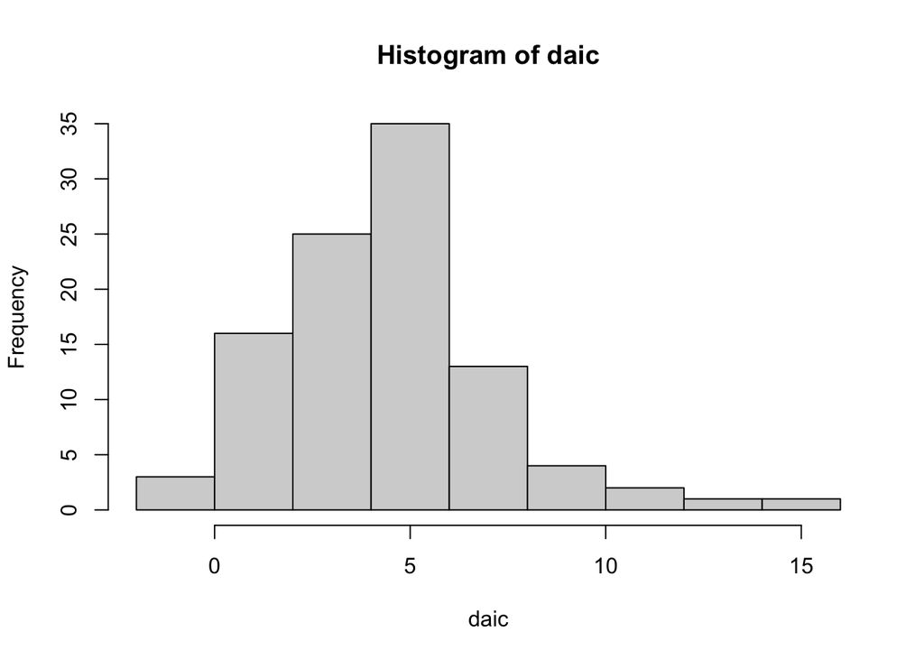

```r
cid.aic=get_item(readRDS(file='R/data/out/lik-CID4-phy_CID4-1000tips-100tr.RDS'), 'lnLik') %>% get_aic(., 4)
sem.aic=get_item(readRDS(file='R/data/out/SEM/best_Ln-SEM8_phy_CID4-1000tips-100tr.RDS'), 'lnLik') %>% get_aic(., 2)
daic=cid.aic-sem.aic
hist(daic)
```

## Results

```r
library(rphenoscate)
library(ggplot2)
library(dplyr)
library(tidyr)  # Load tidyr package
```

### Plot AIC results

```r
# read the results
cid.aic <- tibble(
  t100=get_item(readRDS(file='R/data/out/lik-CID4-phy_CID4-100tips-100tr.RDS'), 'lnLik') %>% get_aic(., 4),
  t500=get_item(readRDS(file='R/data/out/lik-CID4-phy_CID4-500tips-100tr.RDS'), 'lnLik') %>% get_aic(., 4),
  t1000=get_item(readRDS(file='R/data/out/lik-CID4-phy_CID4-1000tips-100tr.RDS'), 'lnLik') %>% get_aic(., 4)
)

cid.lik <- tibble(
  t100=get_item(readRDS(file='R/data/out/lik-CID4-phy_CID4-100tips-100tr.RDS'), 'lnLik'),
  t500=get_item(readRDS(file='R/data/out/lik-CID4-phy_CID4-500tips-100tr.RDS'), 'lnLik'),
  t1000=get_item(readRDS(file='R/data/out/lik-CID4-phy_CID4-1000tips-100tr.RDS'), 'lnLik')
)

sem.aic <- tibble(
  t100=get_item(readRDS( file='R/data/out/SEM/best_Ln-SEM8_phy_CID4-100tips-100tr.RDS'), 'lnLik') %>% get_aic(., 2),
  t500=get_item(readRDS( file='R/data/out/SEM/best_Ln-SEM8_phy_CID4-500tips-100tr.RDS'), 'lnLik') %>% get_aic(., 2),
  t1000=get_item(readRDS(file='R/data/out/SEM/best_Ln-SEM8_phy_CID4-1000tips-100tr.RDS'), 'lnLik') %>% get_aic(., 2)
)


sem.lik <- tibble(
  t100=get_item(readRDS( file='R/data/out/SEM/best_Ln-SEM8_phy_CID4-100tips-100tr.RDS'), 'lnLik'),
  t500=get_item(readRDS( file='R/data/out/SEM/best_Ln-SEM8_phy_CID4-500tips-100tr.RDS'), 'lnLik'),
  t1000=get_item(readRDS(file='R/data/out/SEM/best_Ln-SEM8_phy_CID4-1000tips-100tr.RDS'), 'lnLik')
)
```

MLE of SEM varies from being better than of the original CID to being worse.

```r
del.lik <- cid.lik - sem.lik

# The positive values indicate that CID's MLE is better, negative that SEM is better
apply(del.lik, 2, min)
```

```
##      t100      t500     t1000
## -3.092653 -3.457031 -5.891659
```

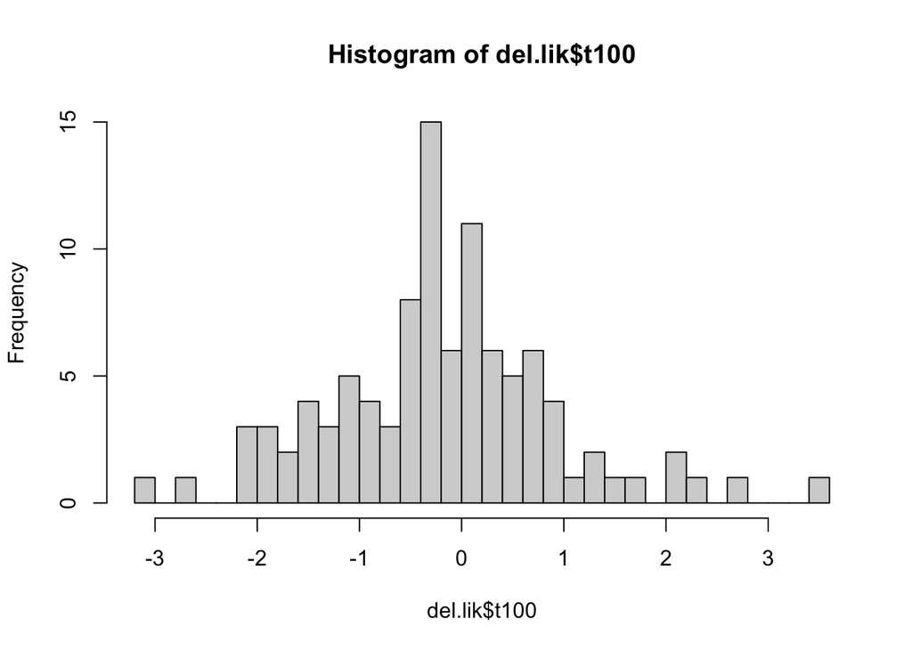

```r
hist(del.lik$t100, breaks = 30)
```

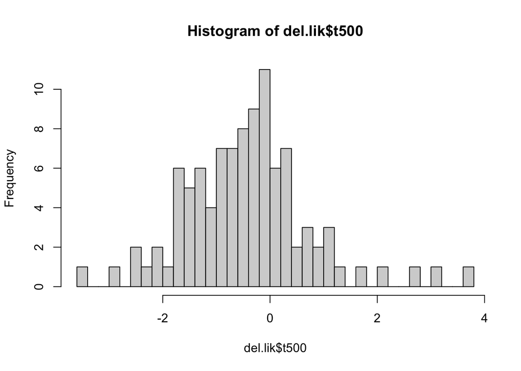

```r
hist(del.lik$t500, breaks = 30)
```

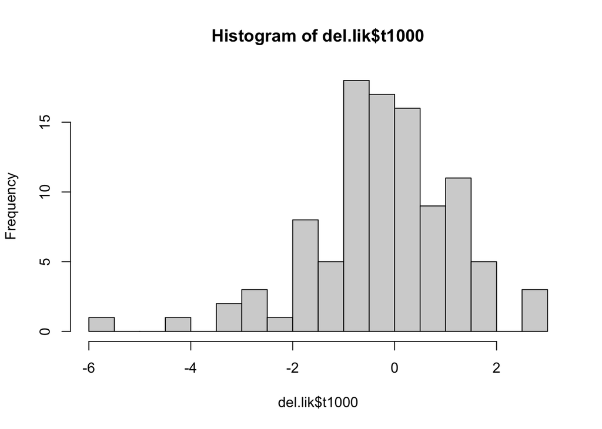

```r
hist(del.lik$t1000, breaks = 30)
```

```r
# proportion of trials supportiing SEM
(which(del.lik$t100 < 0) %>% length)/100
```

```
## [1] 0.58
```

```r
(which(del.lik$t500 < 0) %>% length)/100
```

```
## [1] 0.71
```

```r
(which(del.lik$t1000 < 0) %>% length)/100
```

```
## [1] 0.56
```

```r
# [1] 0.58
# [1] 0.71
# [1] 0.56
```

Get dAIC

```r
# get max delta aic
del.aic <- cid.aic-sem.aic
apply(del.aic, 2, max)
```

```
##     t100     t500    t1000
## 10.18531 10.91406 15.78332
```

```r
apply(del.aic, 2, min)
```

```
##      t100      t500     t1000
## -2.829879 -3.421011 -1.815104
```

```r
# Calculate ECDF for each column
ecdf_del <- del.aic %>%
  summarise(
    t100_ecdf = ecdf(t100),
    t500_ecdf = ecdf(t500),
    t1000_ecdf = ecdf(t1000)
  )


# # Create a data frame for plotting
# ecdf_data <- data.frame(
#   Value = c(del.aic$t100, del.aic$t500),
#   Group = rep(c("100 tips", "500 tips"), each = nrow(del.aic))
# )

# Create a data frame for plotting
ecdf_data <- data.frame(
  Value = c(del.aic$t100, del.aic$t500, del.aic$t1000),
  Group = rep(c("100 tips", "500 tips", "1000 tips"), each = nrow(del.aic))
)
```

ECDF: Proportion of trials with dAIC > 2.

```r
1-ecdf_del$t100_ecdf(2)
```

```
## [1] 0.9
```

```r
1-ecdf_del$t500_ecdf(2)
```

```
## [1] 0.91
```

```r
1-ecdf_del$t1000_ecdf(2)
```

```
## [1] 0.81
```

#### Plot AIC

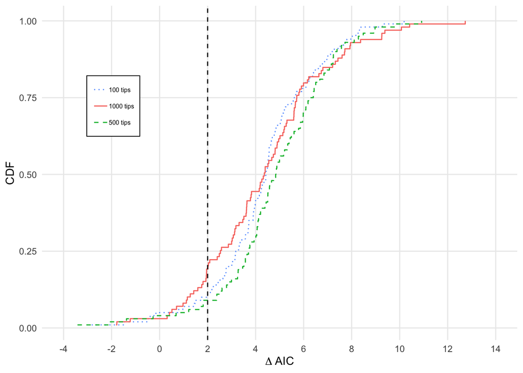

```r
# Define linetypes for each group
linetypes <- c("100 tips" = "dotted", "500 tips" = "dashed", "1000 tips" = "solid")
colortypes <- c("100 tips" = "#619CFF", "500 tips" = "#00BA38", "1000 tips" = "#F8766D")
#linetypes <- c("100 tips" = "dotted", "500 tips" = "dashed")

# Plot the ECDFs for each group with varying linetypes
cdf_plot <- ggplot() +
  stat_ecdf(data = ecdf_data, aes(x = Value, linetype = Group, color=Group), geom = "step", pad = F, size = .5) +
  labs(x = expression(Delta~AIC), y = "CDF") +
  theme_minimal()+
  scale_x_continuous(
    limits = c(-4, 14),
    #breaks = seq(-4, 12, by = 1)
    breaks = seq(-4, 14, by = 2)
  ) +
  scale_linetype_manual(values = linetypes) + # Apply manual linetype scale
  scale_color_manual(values = colortypes) +
  theme(
    panel.grid.minor.x = element_blank(),  # Remove minor grid lines on the x-axis
    panel.grid.minor.y = element_blank()
  ) +
  #guides(color = guide_legend(title = NULL)) +
  #guides(color = 'none') +
  geom_vline(xintercept = 2, linetype = "dashed", color = "black", size = 0.5) +
  theme(
    #plot.background = element_rect(fill = "white"),
    #panel.background = element_rect(fill = "white"),
    legend.box.background = element_rect(fill = "white"),
    legend.text = element_text(size = 6),
    legend.key.size = unit(1.1, "lines"),
    legend.title = element_text(size = 0),
    legend.position = c(0.15, 0.70)
)
cdf_plot
```

```r
# Save the plot with a specific width in centimeters
#ggsave("Figs/cdf-sem_AIC.png", plot = cdf_plot , width = 8.7, height = 5, units = "cm")
```

### Plot AIC and BIC results

```r
# read the results
cid.bic <- tibble(
  t100=get_item(readRDS(file='R/data/out/lik-CID4-phy_CID4-100tips-100tr.RDS'), 'lnLik') %>% get_bic(., 4, 100),
  t500=get_item(readRDS(file='R/data/out/lik-CID4-phy_CID4-500tips-100tr.RDS'), 'lnLik') %>% get_bic(., 4, 500),
  t1000=get_item(readRDS(file='R/data/out/lik-CID4-phy_CID4-1000tips-100tr.RDS'), 'lnLik') %>% get_bic(., 4, 1000)
)

sem.bic <- tibble(
  t100=get_item(readRDS( file='R/data/out/SEM/best_Ln-SEM8_phy_CID4-100tips-100tr.RDS'), 'lnLik') %>% get_bic(., 2, 100),
  t500=get_item(readRDS( file='R/data/out/SEM/best_Ln-SEM8_phy_CID4-500tips-100tr.RDS'), 'lnLik') %>% get_bic(., 2, 500),
  t1000=get_item(readRDS(file='R/data/out/SEM/best_Ln-SEM8_phy_CID4-1000tips-100tr.RDS'), 'lnLik') %>% get_bic(., 2, 1000)
)
```

Get dBIC

```r
# get max delta aic
del.bic <- cid.bic-sem.bic
apply(del.bic, 2, max)
```

```
##     t100     t500    t1000
## 15.39565 19.34328 25.59883
```

```r
apply(del.bic, 2, min)
```

```
##     t100     t500    t1000
## 2.380461 5.008206 8.000406
```

```r
# Calculate ECDF for each column
ecdf_del_bic <- del.bic %>%
  summarise(
    t100_ecdf = ecdf(t100),
    t500_ecdf = ecdf(t500),
    t1000_ecdf = ecdf(t1000)
  )


# Create a data frame for plotting
ecdf_data_bic <- data.frame(
  Value = c(del.bic$t100, del.bic$t500, del.bic$t1000),
  Group = rep(c("100 tips", "500 tips", "1000 tips"), each = nrow(del.bic))
)
```

ECDF: Proportion of trials with dBIC > 2.

```r
1-ecdf_del_bic$t100_ecdf(2)
```

```
## [1] 1
```

```r
1-ecdf_del_bic$t500_ecdf(2)
```

```
## [1] 1
```

```r
1-ecdf_del_bic$t1000_ecdf(2)
```

```
## [1] 1
```

Combine AIC and BIC

```r
# Bind the two dataframes by rows
ecdf_data_combined <- rbind(mutate(ecdf_data, IC = 'AIC'), mutate(ecdf_data_bic, IC = 'BIC'))

#ecdf_data_combined %>% filter(is.finite(Value))
```

#### Plot

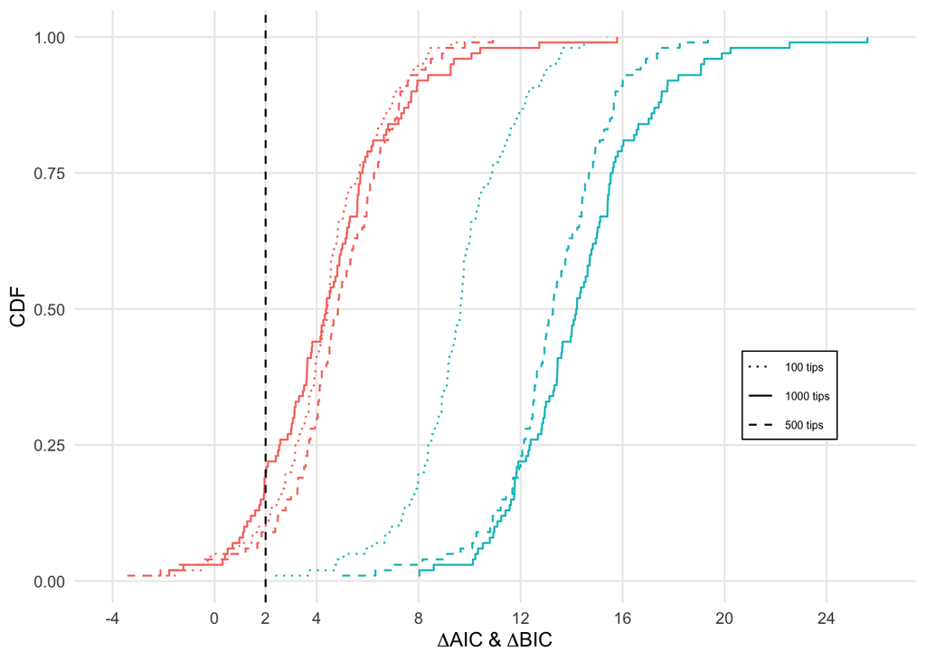

```r
# Define linetypes for each group
linetypes <- c("100 tips" = "dotted", "500 tips" = "dashed", "1000 tips" = "solid")
colortypes <- c("100 tips" = "#619CFF", "500 tips" = "#00BA38", "1000 tips" = "#F8766D")
#linetypes <- c("100 tips" = "dotted", "500 tips" = "dashed")

# Plot the ECDFs for each group with varying linetypes
cdf_plot <- ggplot() +
  stat_ecdf(data = ecdf_data_combined, aes(x = Value, linetype = Group, color=IC), geom = "step", pad = F, size = .5) +
  labs(x = expression(Delta*AIC~"&"~Delta*BIC), y = "CDF") +
  theme_minimal()+
  scale_x_continuous(
    limits = c(-4, 26),
    breaks = c(c(-4, 0, 2),seq(4, 26, by = 4))
    #breaks = seq(-4, 26, by = 4)
  ) +
  scale_linetype_manual(values = linetypes, name = NULL) + # Apply manual linetype scale
  scale_color_discrete(guide = "none", name = NULL) +
  #scale_color_manual(values = colortypes) +
  theme(
    panel.grid.minor.x = element_blank(),  # Remove minor grid lines on the x-axis
    panel.grid.minor.y = element_blank()
  ) +
  geom_vline(xintercept = 2, linetype = "dashed", color = "black", size = 0.5) +
  theme(
    legend.box.background = element_rect(fill = "white"),
    legend.text = element_text(size = 6),
    legend.key.size = unit(1.1, "lines"),
    #legend.position = c(0.15, 0.70),
    legend.position = c(0.85, 0.35),
    legend.margin = margin(0, 0, 0, 0),
    legend.box.margin = margin(-5, 4, 0, 2)
    #legend.spacing = unit(0.01, "cm")
)

cdf_plot
```

```r
# Save the plot with a specific width in centimeters
#ggsave("Figs/cdf.png", plot = cdf_plot , width = 8.7, height = 5, units = "cm")
```

### Unique Q matrices

A high number of unique Q matrices indicates that, by chance, a different model is almost always selected as the best.

```r
# 100 tips
Q_100 <- readRDS( file='R/data/out/SEM/best_Qs-SEM8_phy_CID4-100tips-100tr.RDS')
N_unique_Qs(Q_100)
```

```
## [1] 92
```

```r
# [1] 92

# 500 tips
Q_500 <- readRDS( file='R/data/out/SEM/best_Qs-SEM8_phy_CID4-500tips-100tr.RDS')
N_unique_Qs(Q_500)
```

```
## [1] 86
```

```r
# [1] 86

# 1000 tips
Q_1000 <- readRDS( file='R/data/out/SEM/best_Qs-SEM8_phy_CID4-1000tips-100tr.RDS')
N_unique_Qs(Q_1000)
```

```
## [1] 68
```

```r
# [1] 68
```

Here, we calculate proportions of unique Qs in models with dAIC >2 (SEM8 is preffered)

```r
#del.aic$t100, del.aic$t500, del.aic$t1000

# 100 tips
Q_100 <- readRDS( file='R/data/out/SEM/best_Qs-SEM8_phy_CID4-100tips-100tr.RDS')
index=which(del.aic$t100 >2 )
Q_selected=Q_100[index]
Q_unique=N_unique_Qs(Q_selected)
length(Q_selected)/length(Q_unique)
```

```
## [1] 90
```

```r
# 500 tips
Q_500 <- readRDS( file='R/data/out/SEM/best_Qs-SEM8_phy_CID4-500tips-100tr.RDS')
index=which(del.aic$t500 >2 )
Q_selected=Q_500[index]
Q_unique=N_unique_Qs(Q_selected)
length(Q_selected)/length(Q_unique)
```

```
## [1] 91
```

```r
# 1000 tips
Q_1000 <- readRDS( file='R/data/out/SEM/best_Qs-SEM8_phy_CID4-1000tips-100tr.RDS')
index=which(del.aic$t1000 >2 )
Q_selected=Q_1000[index]
Q_unique=N_unique_Qs(Q_selected)
length(Q_selected)/length(Q_unique)
```

```
## [1] 81
```

### Checking if the selected models are irreducible and trait-dependent

Checking if Qs are lumpable, if they are not lumpable, it means they are irreducible models. In our analyses, all selected best models are irreducible.

```r
# all Qs are not lumpable: is_slumpable() -> False

part_scheme=list(c(1, 2), c(3,4), c(5,6), c(7,8))
lapply(Q_100, function(x) is_slumpable(x, part_scheme)) %>% unlist %>% any()
```

```
## [1] FALSE
```

```r
lapply(Q_500, function(x) is_slumpable(x, part_scheme)) %>% unlist %>% any()
```

```
## [1] FALSE
```

```r
lapply(Q_1000, function(x) is_slumpable(x, part_scheme)) %>% unlist %>% any()
```

```
## [1] FALSE
```

All SEM models tested are trait-dependent due to their lambda tensor. However, we can also examine how many of the selected models have a Q matrix that implies trait-dependence as well. Note a small proportion of Qs in each analysis are trait-independent. However, typically these Q’s imply that trait evolution is diversity-dependent though.

```r
# the function is_trait_INdependent() checks if Q is trait-INdependent
lapply(Q_100, function(x) is_trait_INdependent(x)) %>% unlist %>% sum()
```

```
## [1] 1
```

```r
lapply(Q_500, function(x) is_trait_INdependent(x)) %>% unlist %>% sum()
```

```
## [1] 1
```

```r
lapply(Q_1000, function(x) is_trait_INdependent(x)) %>% unlist %>% sum()
```

```
## [1] 9
```

### Plot Q’s

```r
Qfocal <- Q_100[[1]]
Qfocal
```

```
##    a0 b0 c0 d0 a1 b1 c1 d1
## a0 -4  0  1  0  1  1  0  0
## b0  0 -4  0  0  1  1  0  0
## c0  1  1 -4  0  1  1  1  1
## d0  1  1  0 -4  1  0  1  1
## a1  1  1  0  0 -4  0  1  1
## b1  1  1  0  0  0 -4  0  0
## c1  0  0  1  1  1  1 -4  0
## d1  0  0  0  0  1  1  0 -4
```

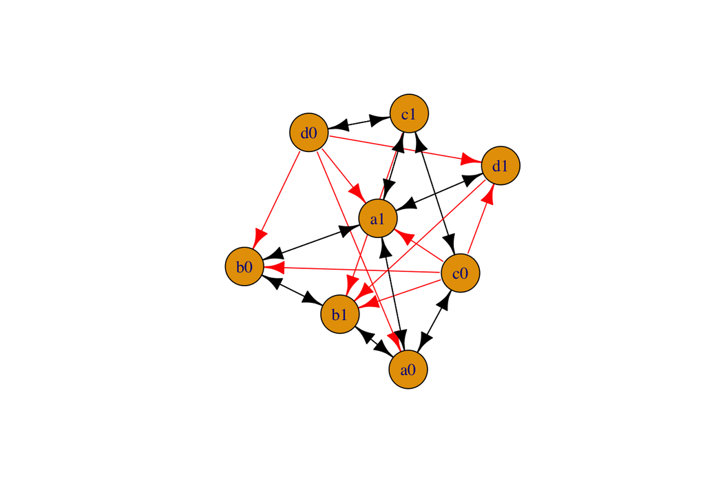

```r
# Plot the graph
g <- create_graph_from_matrix(Qfocal)
unidirectional_edges <- is_unidirectional(g)
plot(g, vertex.label = V(g)$name, vertex.size = 30, edge.color = ifelse(unidirectional_edges, "red", "black"))
```